# Sensitivities, elasticities, and management applications

### 0.1.7 Limitations of sensitivity and elasticity analyses

- Assumption that populations have a stable stage distribution
- They are not enough to describe vital rate dynamics under natural or management conditions: this is because high and low sensitivities and elasticities need to be considered together with the variance of vital rates. For example, a given vital rate with a high elasticity but low variance may be less important than another vital rate with a low elasticity but which changes a lot.

### 0.1.8 Sensitivity analysis methods

#### 0.1.8.1 Manual perturbation

- Compare $\lambda$ SSD after manually changing vital rates
- Two or more vital rates are compared when changed by the same amount or different proportions
- Example: compare a 5% change in adult survival vs. a 10% change in fecundity
- In addition to vital rates, this method allows assessing factors like density dependence, immigration and emigration, age structure, and endogamy (breeding of related individuals resulting in offspring performance reduction)

#### 0.1.8.2 Analytical sensitivity and elasticity analysis

- Comparing different vital rates in terms of how much a small and equal change in each of them affects population growth
- Used to analyze a mean matrix, when little information on population structure or vital rate variation is known
- This type of analysis using a mean matrix can be misleading, as transient dynamics following management are not considered
- In this case, phenomena such as population inertia may occur, in which growth occurs in opposite trends as the predicted by asymptotic elasticity as a result of a large change to a vital rate with a high elasticity
- Sensitivities and elasticities can be calculated for transients and fully stochastic scenarios

#### 0.1.8.3 Management applications

- Recall that, in the broad sense, a sensitivity analysis encompasses these various analytical and simulation techniques we have been talking about
- Such techniques include sensitivity and elasticity calculations together with other important management aspects, such as the joint consideration of vital rate variance and sensitivity/elasticity analyses
- Past and future management actions can be compared in terms of their impacts to vital rates, which ultimately affects population density

One of the first studies which applied sensitivity analysis found that management strategies for endangered loggerhead sea turtles should focus on young adults in the ocean more than hatchlings moving from the sand to the sea. This is because elasticity values for young adult survival are greater than elasticities for eggs and hatchlings. High mortality for young adults was attributed to turtles accidentally trapped in fishing gear. After implementing turtle excluder devices (TED) as a management strategy, temporary population increases were observed (Crouse, Crowder, & Caswell, 1987). A more recent study identified that this strategy has contributed to a deep reduction in turtle mortality, including other endangered species (Finkbeiner et al., 2011). Such findings contribute to the choice and application of successful management strategies which result in population growth of endangered species.

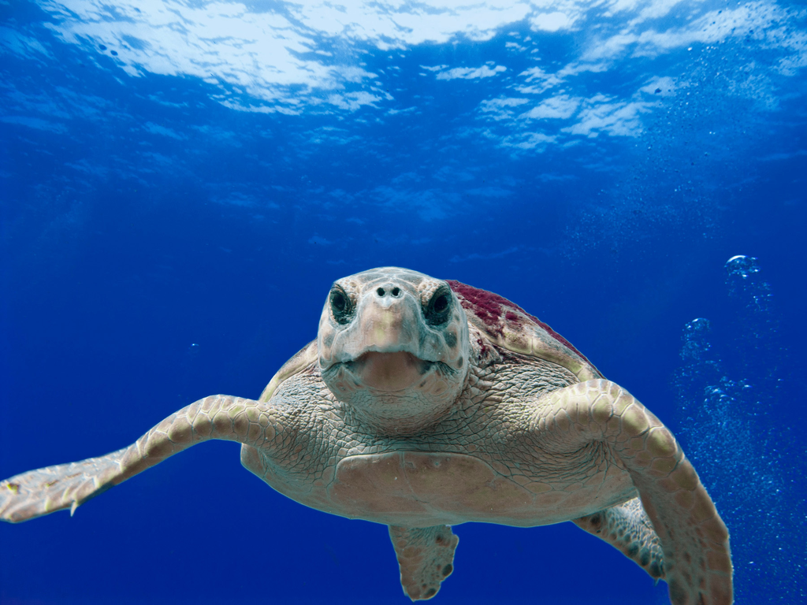

© T. Moore, [Loggerhead Turtle](https://commons.wikimedia.org/wiki/File:Loggerhead_Turtle_%285884715439%29.jpg), Public use provided by the [National Institute of Standards and Technology (NIST), US](https://www.nist.gov/)

#### 0.1.8.4 Analytical sensitivity and elasticity & variance in vital rates

- The extent to which a given vital rate varies needs to be considered together with the analysis of elasticities
- A high elasticity and low variation in a vital rate may make it less important to population growth than another vital rate characterized by a low elasticity but a great variability
- An example is juvenile survival for several species: even if a low elasticity is found for this vital rate, it may be more variable than vital rates for adults, as juveniles have more mortality due to predation, poor conditions, and density-dependent factors
- Mean matrices are not appropriate for this type of analysis, as it requires knowing how much vital rates change in nature or under management and how this change affects population growth

#### 0.1.8.5 Life-stage simulation analysis: method 1

- Uses techniques from both the analytical sensitivity and elasticity analysis and the manual perturbation
- Finds the most important vital rates impacting population growth based on mean rates and on their variation
- A given realistic change to averages and variances in field-collected rates is used to simulate several potential future scenarios
- Vital rate correlations and vital rate distribution functions are specified
- Several matrices are built using the vital rates specified in the distribution function
- $\lambda$ SSD can be calculated for each matrix (What is the probability of this population to increase in time?)
- How similar is the rating of elasticities across replicates (or matrices)?
- To include stochasticity, random vital rates can be used and $\lambda$S can be calculated instead of $\lambda$ SSD

#### 0.1.8.6 Life-stage simulation analysis: method 2

- $\lambda$ values are regressed against each vital rate (for each replicate), considering that all other vital rates are also changing at the same time
- Coefficient of determination (R^2) is corresponds to how much variation in population growth is explained by variation in that specified vital rate
- R^2 values sum to one when analysis considers mean effects and interactions
- Slope of line represents the analytical sensitivity; if using log-transformed data, the slope corresponds to the elasticity
- R^2 is a function of analytical sensitivity and vital rate variance

#### 0.1.8.7 Sensitivity analysis demonstration

Now let’s use an actual population matrix to make a sensitivity analysis and try to figure out the most important vital rates to an oak tree (*Quercus mongolica*) population. In Asia, the native range for this plant, populations have been suffering steep decreases in size due to the spread of a fungal disease vectored by a beetle (Choi et al., 2022).

[figure not shown]

(left) © MPF, [*Quercus mongolica*](https://commons.wikimedia.org/wiki/File:Quercus_mongolica_in_June.jpg), [Creative Commons CC BY-SA 3.0 license](https://creativecommons.org/licenses/by-sa/3.0/deed.en); (right) © William M. Ciesla, [Oak wilt](https://www.invasive.org/browse/detail.cfm?imgnum=0758073#), [Creative Commons CC BY-NC 3.0 license](https://creativecommons.org/licenses/by-nc/3.0/)

It is important to know life history aspects affecting the population growth for this species when predicting disease impacts and planning management actions. A mean matrix for this plant can be found on the [Compadre database](https://compadre-db.org/Species/47241).

```r
# We paste the matrix elements found in the Compadre database
oak <- matrix(c(0.407,0,0,0.606,0.606,
                    0.483,0.701,0,0,0,
                    0.002,0.239,0.832,0,0,
                    0,0,0.117,0.929,0,
                    0,0,0,0.037,0.977), nrow=5, byrow=TRUE,
                  dimnames=list(c("5-8cm","9-16cm","17-32cm","33-64cm",">64cm"),
                  c("5-8cm","9-16cm","17-32cm","33-64cm",">64cm")))

knitr::kable(oak,"simple")
```

|  | 5-8cm | 9-16cm | 17-32cm | 33-64cm | >64cm |
| --- | --- | --- | --- | --- | --- |
| 5-8cm | 0.407 | 0.000 | 0.000 | 0.606 | 0.606 |
| 9-16cm | 0.483 | 0.701 | 0.000 | 0.000 | 0.000 |
| 17-32cm | 0.002 | 0.239 | 0.832 | 0.000 | 0.000 |
| 33-64cm | 0.000 | 0.000 | 0.117 | 0.929 | 0.000 |
| >64cm | 0.000 | 0.000 | 0.000 | 0.037 | 0.977 |

The popbio package calculates sensitivity and elasticity matrices in the same manner as we did in our previous example

```r
library(popbio)
sensit <- sensitivity(oak, zero = FALSE)
knitr::kable(sensit,"simple",caption="Sensitivity matrix")
```

Sensitivity matrix

|  | 5-8cm | 9-16cm | 17-32cm | 33-64cm | >64cm |
| --- | --- | --- | --- | --- | --- |
| 5-8cm | 0.0896726 | 0.1114987 | 0.1042040 | 0.0759845 | 0.0250011 |
| 9-16cm | 0.1258554 | 0.1564882 | 0.1462501 | 0.1066441 | 0.0350890 |
| 17-32cm | 0.2045556 | 0.2543438 | 0.2377036 | 0.1733311 | 0.0570310 |
| 33-64cm | 0.4501133 | 0.5596695 | 0.5230536 | 0.3814054 | 0.1254935 |
| >64cm | 0.4832427 | 0.6008624 | 0.5615516 | 0.4094777 | 0.1347301 |

```r
elast <- elasticity(oak)
knitr::kable(elast,"simple",caption="Elasticity matrix")
```

Elasticity matrix

|  | 5-8cm | 9-16cm | 17-32cm | 33-64cm | >64cm |
| --- | --- | --- | --- | --- | --- |
| 5-8cm | 0.0335001 | 0.0000000 | 0.0000000 | 0.0422658 | 0.0139067 |
| 9-16cm | 0.0557970 | 0.1006912 | 0.0000000 | 0.0000000 | 0.0000000 |
| 17-32cm | 0.0003755 | 0.0557970 | 0.1815311 | 0.0000000 | 0.0000000 |
| 33-64cm | 0.0000000 | 0.0000000 | 0.0561725 | 0.3252329 | 0.0000000 |
| >64cm | 0.0000000 | 0.0000000 | 0.0000000 | 0.0139067 | 0.1208234 |

We can sum up elasticities related to fecundity, stasis, and growth components so that we have an overview of their importance to the demography of our species:

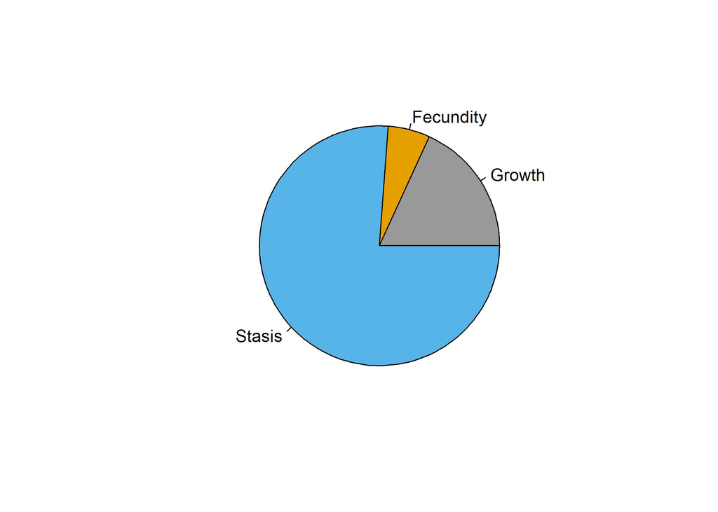

```r
fecund <- sum(elast[1,4:5])
growth <- sum(elast[2,1],elast[3,1:2],elast[4,1:3],elast[5,1:4])
stasis <- sum(diag(elast))

pie(c(growth, fecund, stasis), col = c("#999999", "#E69F00", "#56B4E9"),
    labels=c("Growth", "Fecundity", "Stasis"), cex.lab=1.2, las=1, lwd=1.5)
```

```r
changes <- c(1.05, 1.1, 1.5)

# This function will calculate the changed lambda for each scenario and save as a list
out_matrix <- list()
for (x in 1:length(changes)) {
  result <- matrix(0, nrow=nrow(oak), ncol=nrow(oak))

  for (i in c(1:nrow(oak))) {
    for (j in c(1:nrow(oak))) {
      if (oak[i,j] == 0) {result[i,j] <- 0} else {
        matrix <- oak
        matrix[i,j] <- oak[i,j]*changes[x]
        result[i,j] <- Re(eigen(matrix)$values[1])
      }
    }
  }
  out_matrix[[x]] <- result
}

# Summarize population growth rate change scenarions from our list in a single matrix
summary <- matrix(NA, nrow=length(changes), ncol=length(which(as.vector(t(out_matrix[[1]])) >0)))
for (w in c(1: length(changes))) {
  summary[w,] <- as.vector(t(out_matrix[[w]]))[which(as.vector(t(out_matrix[[w]])) >0)]
}

colnames(summary) <- c("Surv_stas_5-8cm","Reprod_33-64cm","Reprod_>64cm","Surv_grow_5-8cm","Surv_stas_9-16cm",
                       "Surv_grow_5-8cm","Surv_grow_9-16cm","Surv_stas_17-32cm","Surv_grow_17-32cm","Surv_stas_33-64cm","Surv_grow_33-64cm","Surv_stas_>64cm")
```

We can now plot the changed $\lambda$ resulting from the rate change scenarios we simulated. Here we selected a comparison between growth rate changes for survival in 2 immature stages versus 1 mature stage of this population:

[figure not shown]

```r
lower <- 0.8 # To improve visualization, we choose a growth rate as the starting point for plotting results

barplot(summary[,c(4,7,12)]-lower, beside=TRUE, ylim=c(lower, 1.5), ylab="population growth rate",
        col=c("#56B4E9", "#009E73", "#F0E442"), offset= lower, cex.lab=1.2, las=1, lwd=1.5)
abline(h=lower, lwd=2)
abline(h= (Re(eigen(oak)$values[1])), lwd=2, col="red")
legend("topleft", inset=c(0.01,0.01), c("+5% rate change","+10% rate change",
                                         "+15% rate change"),
       fill=c("#56B4E9", "#009E73", "#F0E442"), cex=0.8, lty = c(NA,NA,NA,1))
text(4.5, 1.11, "Lambda", col="red")
```

## 0.2 Resources

- popbio package: https://rdrr.io/cran/popbio/man/01Introduction.html

## 0.3 References

Caswell, H. 2001. *Matrix Population Models* (2nd Edn.). Sinauer Associates, Sunderland, MA.

Caswell, H., & Caswell, H. (2019). Introduction: Sensitivity Analysis–What and Why?. *Sensitivity Analysis: Matrix Methods in Demography and Ecology*, 3-12.

Choi, W. I., Lee, D. H., Jung, J. B., & Park, Y. S. (2022). Oak decline syndrome in Korean forests: History, biology, and prospects for Korean oak wilt. *Forests, 13*(6), 964.

Clark, W. R., Bogenschutz, T. R., & Tessin, D. H. (2008). Sensitivity analyses of a population projection model of ring‐necked pheasants .*The Journal of Wildlife Management, 72*(7), 1605-1613.

Crouse, D. T., Crowder, L. B., & Caswell, H. (1987). A stage‐based population model for loggerhead sea turtles and implications for conservation. *Ecology, 68*(5), 1412-1423.

Finkbeiner, E. M., Wallace, B. P., Moore, J. E., Lewison, R. L., Crowder, L. B., & Read, A. J. (2011). Cumulative estimates of sea turtle bycatch and mortality in USA fisheries between 1990 and 2007. *Biological Conservation, 144*(11), 2719-2727.

Gonzalez de Leon, S., Herrera, I., & Guevara, R. (2016). Mating system, population growth, and management scenario for *Kalanchoe pinnata* in an invaded seasonally dry tropical forest. *Ecology and evolution, 6*(13), 4541-4550.

Manlik, O., Lacy, R. C., & Sherwin, W. B. (2018). Applicability and limitations of sensitivity analyses for wildlife management. *Journal of Applied Ecology, 55*(3), 1430-1440.

Marchioro, C. A., Santos, K. L., & Siminski, A. (2020). Present and future of the critically endangered Araucaria angustifolia due to climate change and habitat loss. *Forestry: An International Journal of Forest Research, 93*(3), 401-410.

Mills, L.S. (2012). *Conservation of wildlife populations*: Demography, genetics, and management. Wiley- Blackwell.

Paludo, G. F., Lauterjung, M. B., dos Reis, M. S., & Mantovani, A. (2016). Inferring population trends of *Araucaria angustifolia* (Araucariaceae) using a transition matrix model in an old-growth forest. *Southern Forests: a Journal of Forest Science, 78*(2), 137-143.

Thomas, P. 2013. *Araucaria angustifolia*. *The IUCN Red List of Threatened Species 2013*: e.T32975A2829141. https://dx.doi.org/10.2305/IUCN.UK.2013-1.RLTS.T32975A2829141.en.